# homework2

Shreyasi Tamhane

2026-09-26

```r
library(readr)
```

# PCA Image Compression

## Image Compression Function

```r
image_compression <- function(x, k) {

  # PCA
  pca <- prcomp(x, center = FALSE, scale. = FALSE)

  # first k PC scores
  Z_k <- pca$x[, 1:k]

  # first k eigenvectors
  U_k <- pca$rotation[, 1:k]

  # rank-k approximation
  x_k <- Z_k %*% t(U_k)

  # calculate the Frobenius error
  error <- sqrt(sum((x - x_k)^2))

  # Return both results
  return(list(
    approximation = x_k,
    error = error,
    eigenvectors = pca$rotation,
    scores = pca$x
  ))
}
```

## Image 1

### Original and PCA Approximations

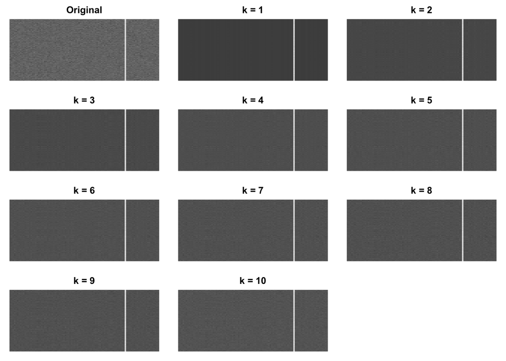

### Approximation Error

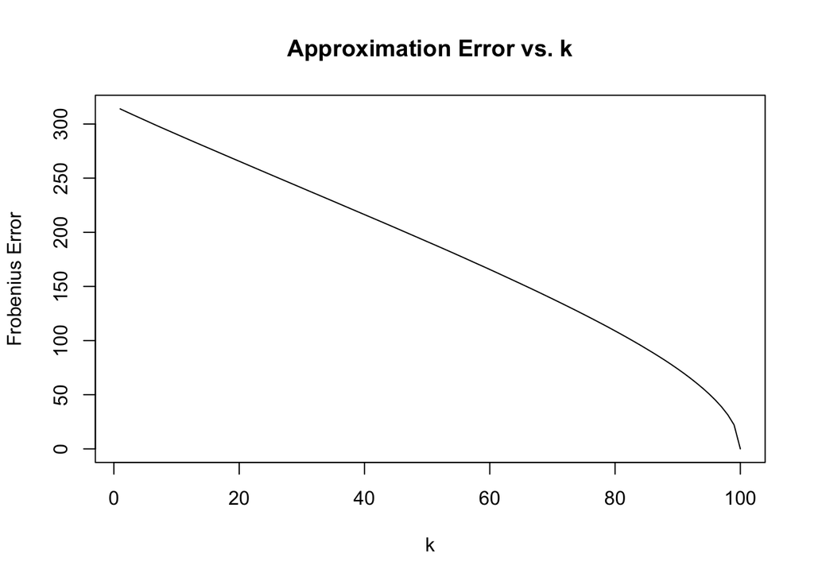

### First Eigenvector

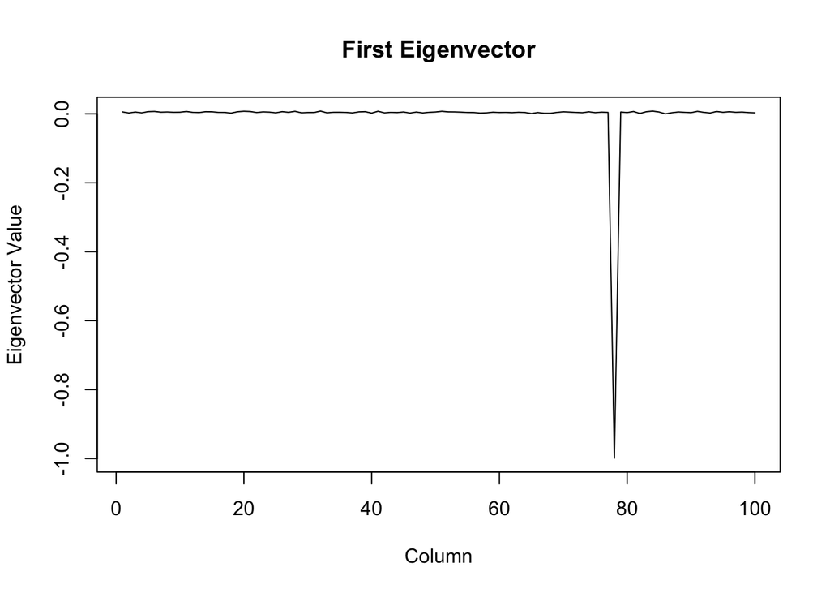

The first eigenvector shows the main direction of variation across the image’s columns. Most columns have values close to zero, while column 78 has a large negative value, indicating that this column contributes strongly to the primary pattern captured by the first principal component.

### First PC Score

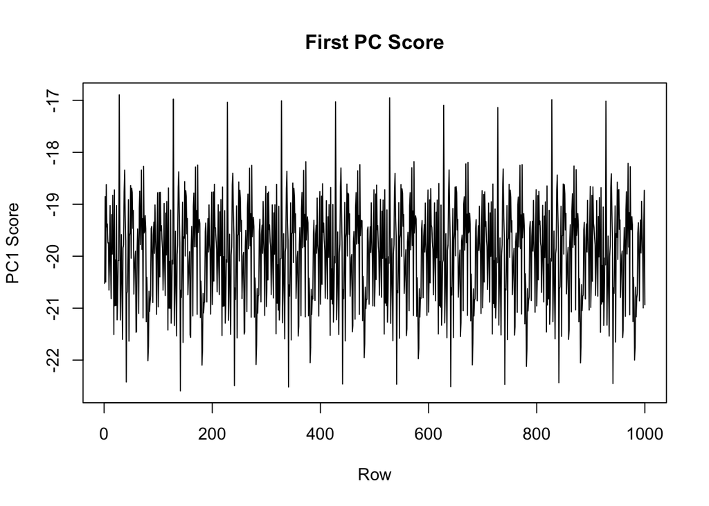

The first PC scores show how strongly each row contributes to the main pattern in the image. Most scores are between approximately -22 and -18, with noticeable variation across rows, indicating that different rows contribute differently to the primary principal component.

### Sufficiently Good Approximation

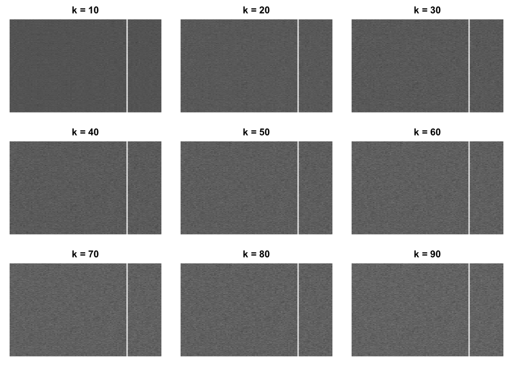

For image 1, I believe $k = 10$ provides a sufficiently good approximation of the original image. The main visual feature of the image is already captured at $k = 10$, and increasing $k$ beyond 10 produces relatively little visible improvement in the image. Therefore, $k=10$ provides a reasonable balance between maintaining the important features of the image and using fewer principal components.

## Image 2

### Original and PCA Approximations

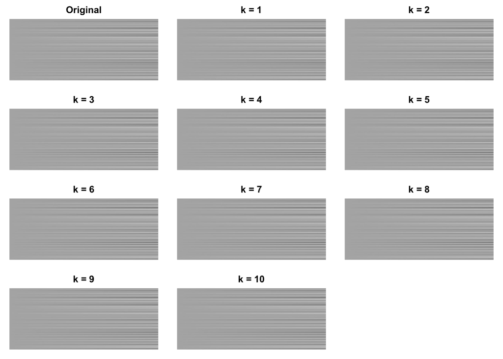

### Approximation Error

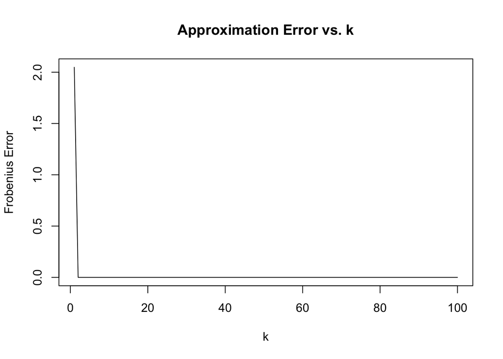

### First Eigenvector

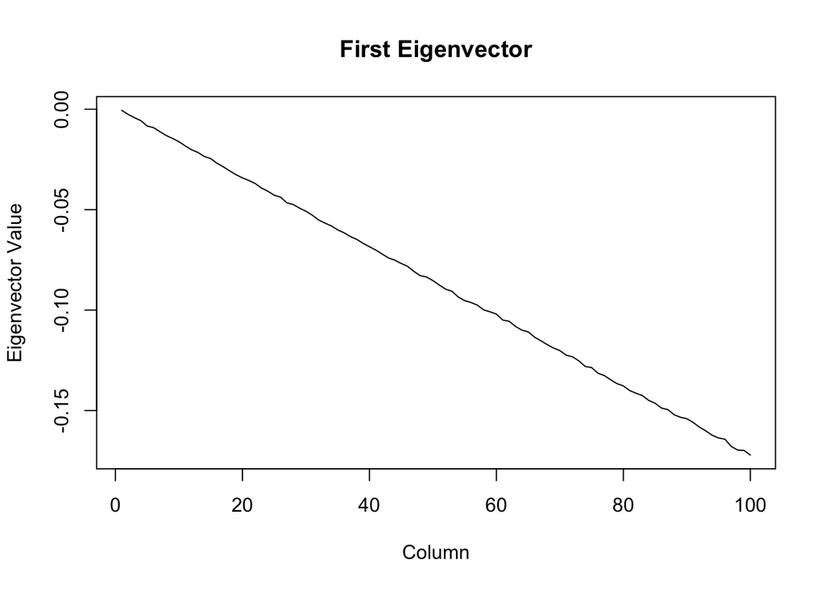

The first eigenvector shows the main direction of variation across the image’s columns. Its values gradually decrease from approximately 0 to -0.17, indicating that the later columns contribute more strongly and negatively to the main pattern captured by the first principal component.

### First PC Score

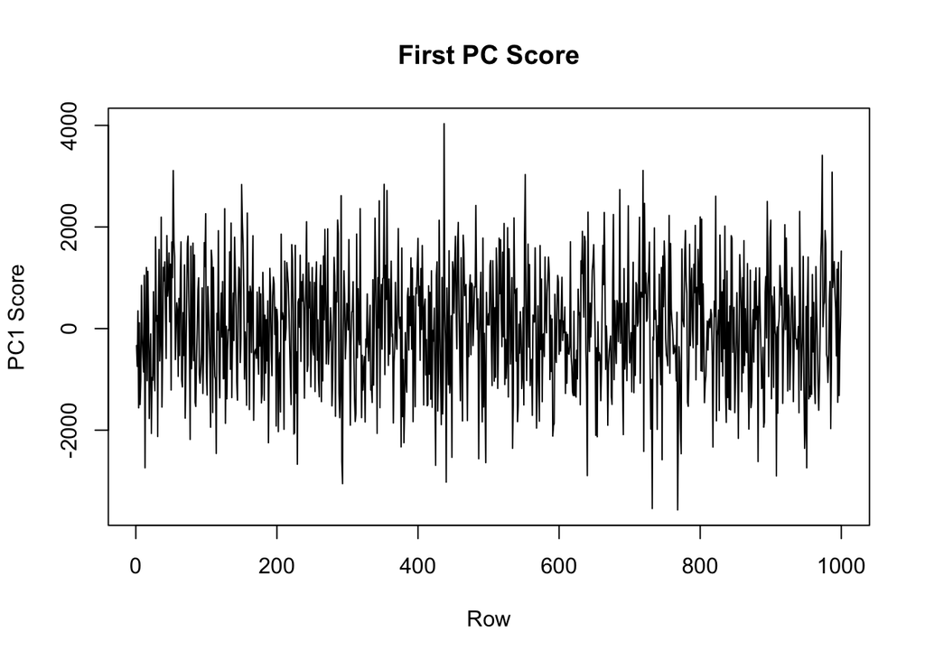

The first PC scores show how strongly each row contributes to the main pattern in the image. The scores vary considerably around 0, indicating that different rows contribute differently to the first principal component, with some rows having particularly large positive or negative contributions.

### Sufficiently Good Approximation

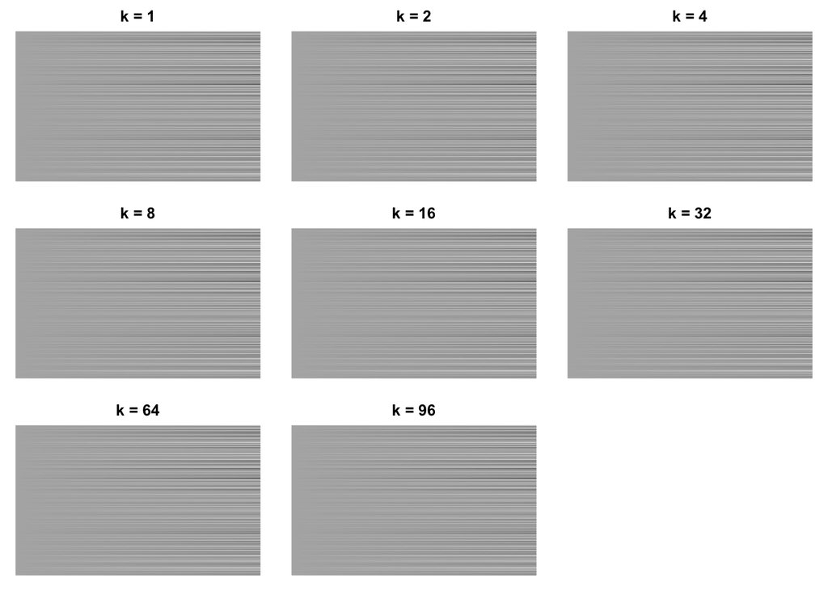

For image 2, I believe a rank-2 approximation is sufficiently good. The main horizontal patterns of the original image are already captured with only two principal components. The Frobenius error drops to nearly zero at $k=2$, and increasing $k$ beyond 2 produces very little visible improvement. Therefore, $k=2$ provides a good balance between preserving the image and reducing the number of components needed to represent it.

## Image 3

### Original and PCA Approximations

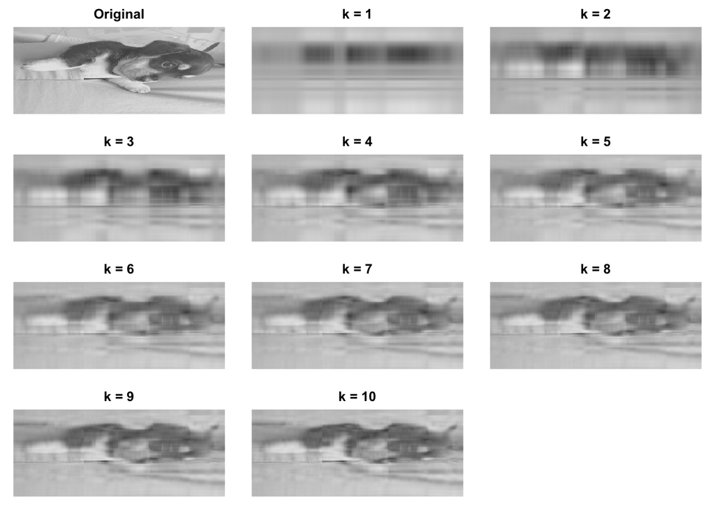

### Approximation Error

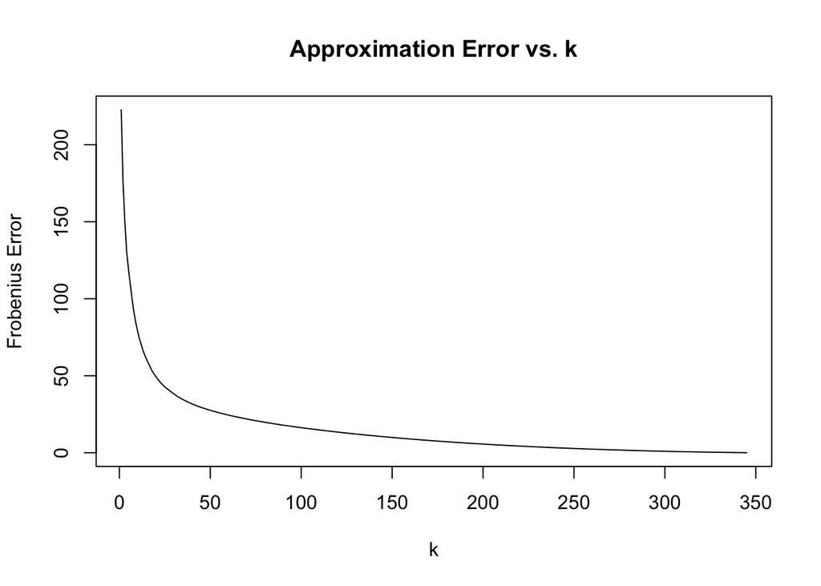

### First Eigenvector

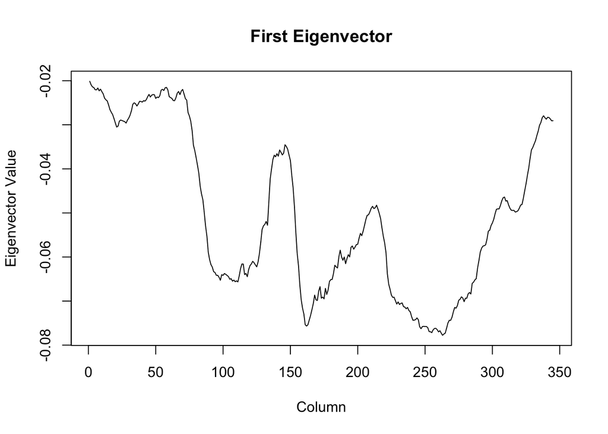

The first eigenvector shows the main direction of variation across the image’s columns. Its values change substantially across the columns, with particularly large negative values around columns 160 and 260. This indicates that different regions of the image contribute differently to the main pattern captured by the first principal component.

### First PC Score

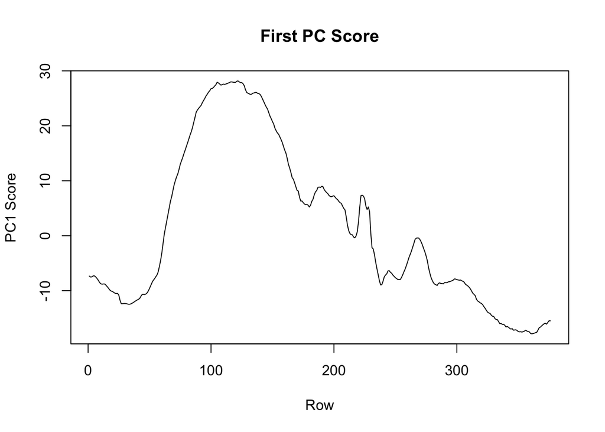

The first PC score represents the contribution of each row to the main pattern of variation in the image. The scores vary considerably across the rows, with the largest positive scores occurring around rows 100–130 and more negative scores occurring near the beginning and end of the image. This indicates that the middle portion of the image contributes most strongly to the primary pattern captured by PCA.

### Sufficiently Good Approximation

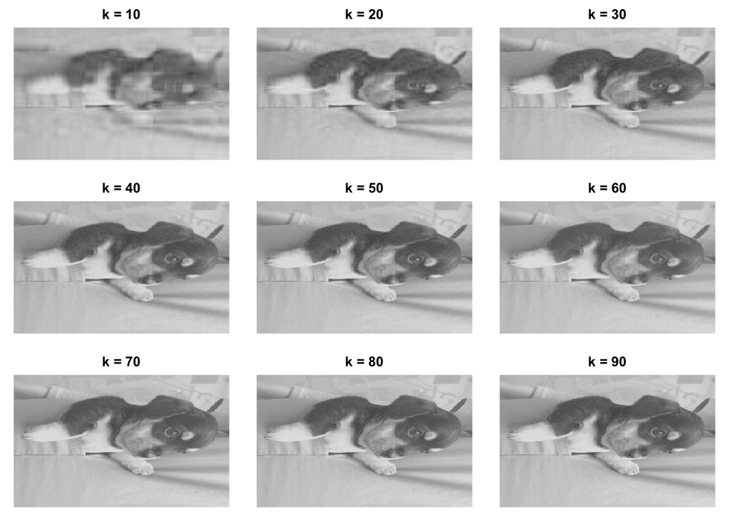

For image 3, I believe a rank-20 approximation is sufficiently good. The main content of the original image are sufficiently captured. The Frobenius error continues to drop after the rank-20 approximation, and the image quality does improve, however $k=20$ provides an adequate presentation. Thus, $k=20$ provides a good balance between preserving the image and reducing the number of components needed to represent it.

## Image 4

### Original and PCA Approximations

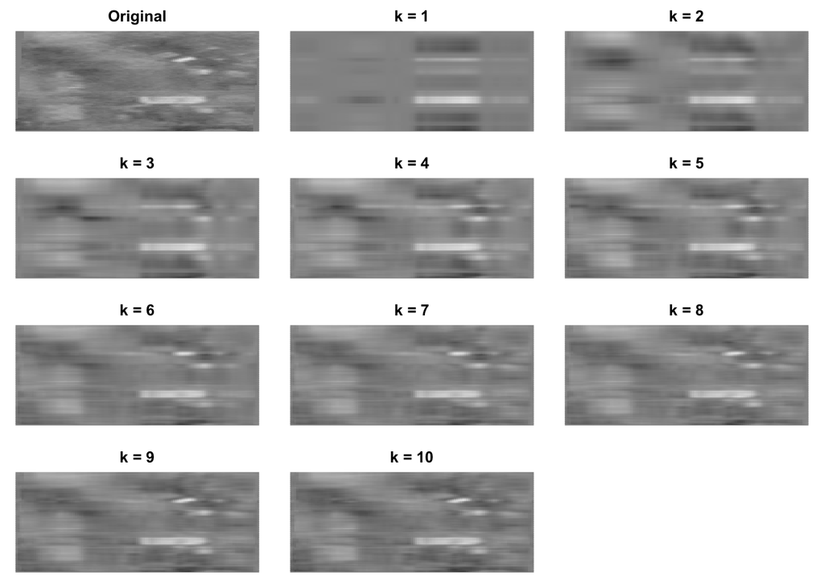

### Approximation Error

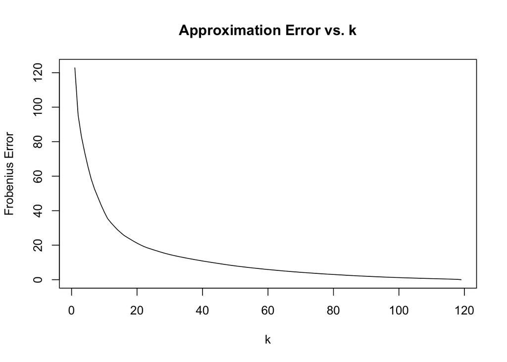

### First Eigenvector

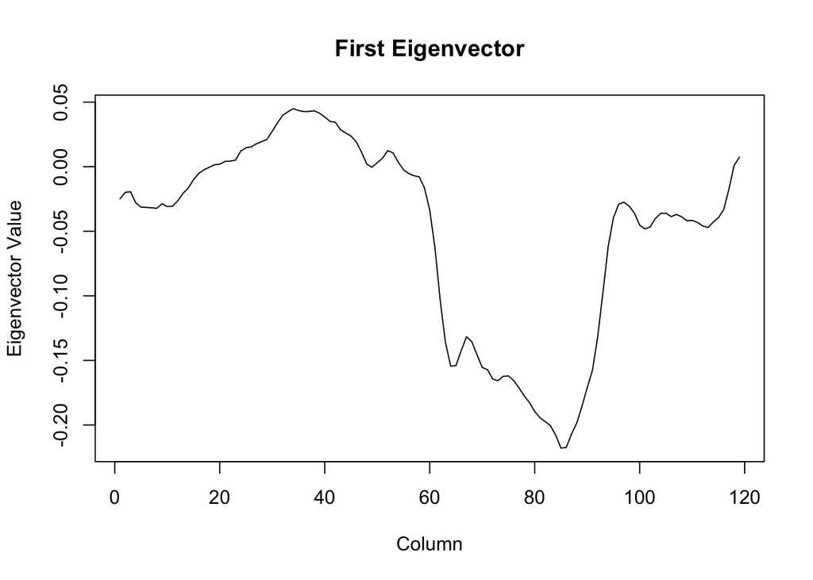

The first eigenvector represents the main direction of variation across the image’s columns. Its values vary across the columns, with larger values around columns 35–40 and more negative values around columns 65 and 85. This indicates that different columns have different weights in the main pattern of variation captured by the first principal component.

### First PC Score

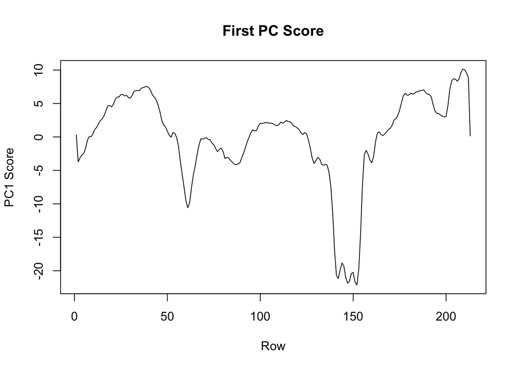

### Sufficiently Good Approximation

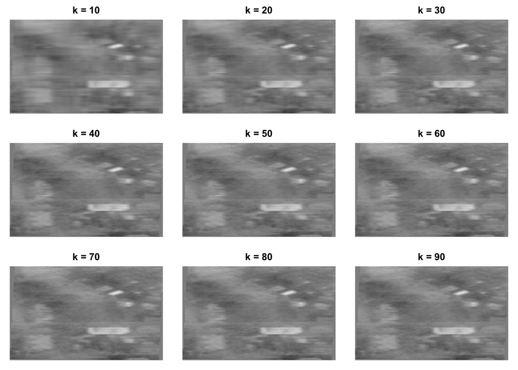